# Risk Factor Analysis

## Outcome Variable

**Outcome Variable:** y_rate_len

## Predictor Variables

**Intervention Variable:** impsan

**Adjustment Set:**

- arm
- sex
- W_mage
- meducyrs
- feducyrs
- hhwealth_quart
- hfoodsec
- W_mhtcm
- W_mwtkg
- W_mbmi
- single
- W_nrooms
- W_parity
- impfloor
- safeh20
- delta_W_mage
- delta_meducyrs
- delta_feducyrs
- delta_hhwealth_quart
- delta_hfoodsec
- delta_W_mhtcm
- delta_W_mwtkg
- delta_W_mbmi
- delta_single
- delta_W_nrooms
- delta_W_parity
- delta_impfloor
- delta_safeh20

## Stratifying Variables

The analysis was stratified on these variable(s):

- agecat
- studyid
- country

## Data Summary

| agecat | studyid | country | impsan | n_cell | n | outcome_variable |
| --- | --- | --- | --- | --- | --- | --- |
| 0-3 months | ki0047075b-MAL-ED | BANGLADESH | 1 | 198 | 236 | y_rate_len |
| 0-3 months | ki0047075b-MAL-ED | BANGLADESH | 0 | 38 | 236 | y_rate_len |
| 0-3 months | ki0047075b-MAL-ED | BRAZIL | 1 | 159 | 163 | y_rate_len |
| 0-3 months | ki0047075b-MAL-ED | BRAZIL | 0 | 4 | 163 | y_rate_len |
| 0-3 months | ki0047075b-MAL-ED | INDIA | 1 | 80 | 176 | y_rate_len |
| 0-3 months | ki0047075b-MAL-ED | INDIA | 0 | 96 | 176 | y_rate_len |
| 0-3 months | ki0047075b-MAL-ED | NEPAL | 1 | 154 | 155 | y_rate_len |
| 0-3 months | ki0047075b-MAL-ED | NEPAL | 0 | 1 | 155 | y_rate_len |
| 0-3 months | ki0047075b-MAL-ED | PERU | 1 | 60 | 246 | y_rate_len |
| 0-3 months | ki0047075b-MAL-ED | PERU | 0 | 186 | 246 | y_rate_len |
| 0-3 months | ki0047075b-MAL-ED | SOUTH AFRICA | 1 | 2 | 194 | y_rate_len |
| 0-3 months | ki0047075b-MAL-ED | SOUTH AFRICA | 0 | 192 | 194 | y_rate_len |
| 0-3 months | ki0047075b-MAL-ED | TANZANIA, UNITED REPUBLIC OF | 1 | 0 | 216 | y_rate_len |
| 0-3 months | ki0047075b-MAL-ED | TANZANIA, UNITED REPUBLIC OF | 0 | 216 | 216 | y_rate_len |
| 0-3 months | ki1017093-NIH-Birth | BANGLADESH | 1 | 218 | 566 | y_rate_len |
| 0-3 months | ki1017093-NIH-Birth | BANGLADESH | 0 | 348 | 566 | y_rate_len |
| 0-3 months | ki1017093b-PROVIDE | BANGLADESH | 1 | 13 | 13 | y_rate_len |
| 0-3 months | ki1017093b-PROVIDE | BANGLADESH | 0 | 0 | 13 | y_rate_len |
| 0-3 months | ki1017093c-NIH-Crypto | BANGLADESH | 1 | 626 | 710 | y_rate_len |
| 0-3 months | ki1017093c-NIH-Crypto | BANGLADESH | 0 | 84 | 710 | y_rate_len |
| 0-3 months | ki1114097-CONTENT | PERU | 1 | 25 | 29 | y_rate_len |
| 0-3 months | ki1114097-CONTENT | PERU | 0 | 4 | 29 | y_rate_len |
| 0-3 months | ki1135781-COHORTS | GUATEMALA | 1 | 42 | 445 | y_rate_len |
| 0-3 months | ki1135781-COHORTS | GUATEMALA | 0 | 403 | 445 | y_rate_len |
| 0-3 months | ki1135781-COHORTS | INDIA | 1 | 1732 | 4660 | y_rate_len |
| 0-3 months | ki1135781-COHORTS | INDIA | 0 | 2928 | 4660 | y_rate_len |
| 0-3 months | kiGH5241-JiVitA-3 | BANGLADESH | 1 | 13596 | 19862 | y_rate_len |
| 0-3 months | kiGH5241-JiVitA-3 | BANGLADESH | 0 | 6266 | 19862 | y_rate_len |
| 0-3 months | kiGH5241-JiVitA-4 | BANGLADESH | 1 | 1951 | 2513 | y_rate_len |
| 0-3 months | kiGH5241-JiVitA-4 | BANGLADESH | 0 | 562 | 2513 | y_rate_len |

[output cut: 198 more lines]

The following strata were considered:

- agecat: 0-3 months, studyid: ki0047075b-MAL-ED, country: BANGLADESH
- agecat: 0-3 months, studyid: ki0047075b-MAL-ED, country: BRAZIL
- agecat: 0-3 months, studyid: ki0047075b-MAL-ED, country: INDIA
- agecat: 0-3 months, studyid: ki0047075b-MAL-ED, country: NEPAL
- agecat: 0-3 months, studyid: ki0047075b-MAL-ED, country: PERU
- agecat: 0-3 months, studyid: ki0047075b-MAL-ED, country: SOUTH AFRICA
- agecat: 0-3 months, studyid: ki0047075b-MAL-ED, country: TANZANIA, UNITED REPUBLIC OF
- agecat: 0-3 months, studyid: ki1017093-NIH-Birth, country: BANGLADESH
- agecat: 0-3 months, studyid: ki1017093b-PROVIDE, country: BANGLADESH
- agecat: 0-3 months, studyid: ki1017093c-NIH-Crypto, country: BANGLADESH
- agecat: 0-3 months, studyid: ki1114097-CONTENT, country: PERU
- agecat: 0-3 months, studyid: ki1135781-COHORTS, country: GUATEMALA
- agecat: 0-3 months, studyid: ki1135781-COHORTS, country: INDIA
- agecat: 0-3 months, studyid: kiGH5241-JiVitA-3, country: BANGLADESH
- agecat: 0-3 months, studyid: kiGH5241-JiVitA-4, country: BANGLADESH
- agecat: 12-15 months, studyid: ki0047075b-MAL-ED, country: BANGLADESH
- agecat: 12-15 months, studyid: ki0047075b-MAL-ED, country: BRAZIL
- agecat: 12-15 months, studyid: ki0047075b-MAL-ED, country: INDIA
- agecat: 12-15 months, studyid: ki0047075b-MAL-ED, country: NEPAL
- agecat: 12-15 months, studyid: ki0047075b-MAL-ED, country: PERU
- agecat: 12-15 months, studyid: ki0047075b-MAL-ED, country: SOUTH AFRICA
- agecat: 12-15 months, studyid: ki0047075b-MAL-ED, country: TANZANIA, UNITED REPUBLIC OF
- agecat: 12-15 months, studyid: ki1017093-NIH-Birth, country: BANGLADESH
- agecat: 12-15 months, studyid: ki1017093b-PROVIDE, country: BANGLADESH
- agecat: 12-15 months, studyid: ki1017093c-NIH-Crypto, country: BANGLADESH
- agecat: 12-15 months, studyid: ki1114097-CONTENT, country: PERU
- agecat: 12-15 months, studyid: ki1135781-COHORTS, country: GUATEMALA
- agecat: 12-15 months, studyid: ki1148112-LCNI-5, country: MALAWI
- agecat: 12-15 months, studyid: kiGH5241-JiVitA-4, country: BANGLADESH
- agecat: 15-18 months, studyid: ki0047075b-MAL-ED, country: BANGLADESH
- agecat: 15-18 months, studyid: ki0047075b-MAL-ED, country: BRAZIL
- agecat: 15-18 months, studyid: ki0047075b-MAL-ED, country: INDIA
- agecat: 15-18 months, studyid: ki0047075b-MAL-ED, country: NEPAL
- agecat: 15-18 months, studyid: ki0047075b-MAL-ED, country: PERU
- agecat: 15-18 months, studyid: ki0047075b-MAL-ED, country: SOUTH AFRICA
- agecat: 15-18 months, studyid: ki0047075b-MAL-ED, country: TANZANIA, UNITED REPUBLIC OF
- agecat: 15-18 months, studyid: ki1017093-NIH-Birth, country: BANGLADESH
- agecat: 15-18 months, studyid: ki1017093b-PROVIDE, country: BANGLADESH
- agecat: 15-18 months, studyid: ki1017093c-NIH-Crypto, country: BANGLADESH
- agecat: 15-18 months, studyid: ki1114097-CONTENT, country: PERU
- agecat: 15-18 months, studyid: ki1135781-COHORTS, country: GUATEMALA
- agecat: 15-18 months, studyid: ki1148112-LCNI-5, country: MALAWI
- agecat: 15-18 months, studyid: kiGH5241-JiVitA-4, country: BANGLADESH
- agecat: 18-21 months, studyid: ki0047075b-MAL-ED, country: BANGLADESH
- agecat: 18-21 months, studyid: ki0047075b-MAL-ED, country: BRAZIL
- agecat: 18-21 months, studyid: ki0047075b-MAL-ED, country: INDIA
- agecat: 18-21 months, studyid: ki0047075b-MAL-ED, country: NEPAL
- agecat: 18-21 months, studyid: ki0047075b-MAL-ED, country: PERU
- agecat: 18-21 months, studyid: ki0047075b-MAL-ED, country: SOUTH AFRICA
- agecat: 18-21 months, studyid: ki0047075b-MAL-ED, country: TANZANIA, UNITED REPUBLIC OF
- agecat: 18-21 months, studyid: ki1017093-NIH-Birth, country: BANGLADESH
- agecat: 18-21 months, studyid: ki1017093b-PROVIDE, country: BANGLADESH
- agecat: 18-21 months, studyid: ki1017093c-NIH-Crypto, country: BANGLADESH
- agecat: 18-21 months, studyid: ki1114097-CONTENT, country: PERU
- agecat: 18-21 months, studyid: ki1135781-COHORTS, country: GUATEMALA
- agecat: 18-21 months, studyid: ki1148112-LCNI-5, country: MALAWI
- agecat: 21-24 months, studyid: ki0047075b-MAL-ED, country: BANGLADESH
- agecat: 21-24 months, studyid: ki0047075b-MAL-ED, country: BRAZIL
- agecat: 21-24 months, studyid: ki0047075b-MAL-ED, country: INDIA
- agecat: 21-24 months, studyid: ki0047075b-MAL-ED, country: NEPAL
- agecat: 21-24 months, studyid: ki0047075b-MAL-ED, country: PERU
- agecat: 21-24 months, studyid: ki0047075b-MAL-ED, country: SOUTH AFRICA
- agecat: 21-24 months, studyid: ki0047075b-MAL-ED, country: TANZANIA, UNITED REPUBLIC OF
- agecat: 21-24 months, studyid: ki1017093-NIH-Birth, country: BANGLADESH
- agecat: 21-24 months, studyid: ki1017093b-PROVIDE, country: BANGLADESH
- agecat: 21-24 months, studyid: ki1017093c-NIH-Crypto, country: BANGLADESH
- agecat: 21-24 months, studyid: ki1114097-CONTENT, country: PERU
- agecat: 21-24 months, studyid: ki1135781-COHORTS, country: GUATEMALA
- agecat: 21-24 months, studyid: ki1148112-LCNI-5, country: MALAWI
- agecat: 3-6 months, studyid: ki0047075b-MAL-ED, country: BANGLADESH
- agecat: 3-6 months, studyid: ki0047075b-MAL-ED, country: BRAZIL
- agecat: 3-6 months, studyid: ki0047075b-MAL-ED, country: INDIA
- agecat: 3-6 months, studyid: ki0047075b-MAL-ED, country: NEPAL
- agecat: 3-6 months, studyid: ki0047075b-MAL-ED, country: PERU
- agecat: 3-6 months, studyid: ki0047075b-MAL-ED, country: SOUTH AFRICA
- agecat: 3-6 months, studyid: ki0047075b-MAL-ED, country: TANZANIA, UNITED REPUBLIC OF
- agecat: 3-6 months, studyid: ki1017093-NIH-Birth, country: BANGLADESH
- agecat: 3-6 months, studyid: ki1017093b-PROVIDE, country: BANGLADESH
- agecat: 3-6 months, studyid: ki1017093c-NIH-Crypto, country: BANGLADESH
- agecat: 3-6 months, studyid: ki1114097-CONTENT, country: PERU
- agecat: 3-6 months, studyid: ki1135781-COHORTS, country: GUATEMALA
- agecat: 3-6 months, studyid: ki1135781-COHORTS, country: INDIA
- agecat: 3-6 months, studyid: kiGH5241-JiVitA-3, country: BANGLADESH
- agecat: 3-6 months, studyid: kiGH5241-JiVitA-4, country: BANGLADESH
- agecat: 6-9 months, studyid: ki0047075b-MAL-ED, country: BANGLADESH
- agecat: 6-9 months, studyid: ki0047075b-MAL-ED, country: BRAZIL
- agecat: 6-9 months, studyid: ki0047075b-MAL-ED, country: INDIA
- agecat: 6-9 months, studyid: ki0047075b-MAL-ED, country: NEPAL
- agecat: 6-9 months, studyid: ki0047075b-MAL-ED, country: PERU
- agecat: 6-9 months, studyid: ki0047075b-MAL-ED, country: SOUTH AFRICA
- agecat: 6-9 months, studyid: ki0047075b-MAL-ED, country: TANZANIA, UNITED REPUBLIC OF
- agecat: 6-9 months, studyid: ki1017093-NIH-Birth, country: BANGLADESH
- agecat: 6-9 months, studyid: ki1017093b-PROVIDE, country: BANGLADESH
- agecat: 6-9 months, studyid: ki1017093c-NIH-Crypto, country: BANGLADESH
- agecat: 6-9 months, studyid: ki1114097-CONTENT, country: PERU
- agecat: 6-9 months, studyid: ki1135781-COHORTS, country: GUATEMALA
- agecat: 6-9 months, studyid: ki1135781-COHORTS, country: INDIA
- agecat: 6-9 months, studyid: ki1148112-LCNI-5, country: MALAWI
- agecat: 6-9 months, studyid: kiGH5241-JiVitA-4, country: BANGLADESH
- agecat: 9-12 months, studyid: ki0047075b-MAL-ED, country: BANGLADESH
- agecat: 9-12 months, studyid: ki0047075b-MAL-ED, country: BRAZIL
- agecat: 9-12 months, studyid: ki0047075b-MAL-ED, country: INDIA
- agecat: 9-12 months, studyid: ki0047075b-MAL-ED, country: NEPAL
- agecat: 9-12 months, studyid: ki0047075b-MAL-ED, country: PERU
- agecat: 9-12 months, studyid: ki0047075b-MAL-ED, country: SOUTH AFRICA
- agecat: 9-12 months, studyid: ki0047075b-MAL-ED, country: TANZANIA, UNITED REPUBLIC OF
- agecat: 9-12 months, studyid: ki1017093-NIH-Birth, country: BANGLADESH
- agecat: 9-12 months, studyid: ki1017093b-PROVIDE, country: BANGLADESH
- agecat: 9-12 months, studyid: ki1017093c-NIH-Crypto, country: BANGLADESH
- agecat: 9-12 months, studyid: ki1114097-CONTENT, country: PERU
- agecat: 9-12 months, studyid: ki1135781-COHORTS, country: GUATEMALA
- agecat: 9-12 months, studyid: ki1135781-COHORTS, country: INDIA
- agecat: 9-12 months, studyid: ki1148112-LCNI-5, country: MALAWI
- agecat: 9-12 months, studyid: kiGH5241-JiVitA-4, country: BANGLADESH

### Dropped Strata

Some strata were dropped due to rare outcomes:

- agecat: 0-3 months, studyid: ki0047075b-MAL-ED, country: BRAZIL
- agecat: 0-3 months, studyid: ki0047075b-MAL-ED, country: NEPAL
- agecat: 0-3 months, studyid: ki0047075b-MAL-ED, country: SOUTH AFRICA
- agecat: 0-3 months, studyid: ki0047075b-MAL-ED, country: TANZANIA, UNITED REPUBLIC OF
- agecat: 0-3 months, studyid: ki1017093b-PROVIDE, country: BANGLADESH
- agecat: 0-3 months, studyid: ki1114097-CONTENT, country: PERU
- agecat: 3-6 months, studyid: ki0047075b-MAL-ED, country: BRAZIL
- agecat: 3-6 months, studyid: ki0047075b-MAL-ED, country: NEPAL
- agecat: 3-6 months, studyid: ki0047075b-MAL-ED, country: SOUTH AFRICA
- agecat: 3-6 months, studyid: ki0047075b-MAL-ED, country: TANZANIA, UNITED REPUBLIC OF
- agecat: 3-6 months, studyid: ki1017093b-PROVIDE, country: BANGLADESH
- agecat: 6-9 months, studyid: ki0047075b-MAL-ED, country: BRAZIL
- agecat: 6-9 months, studyid: ki0047075b-MAL-ED, country: NEPAL
- agecat: 6-9 months, studyid: ki0047075b-MAL-ED, country: SOUTH AFRICA
- agecat: 6-9 months, studyid: ki0047075b-MAL-ED, country: TANZANIA, UNITED REPUBLIC OF
- agecat: 6-9 months, studyid: ki1017093b-PROVIDE, country: BANGLADESH
- agecat: 6-9 months, studyid: ki1148112-LCNI-5, country: MALAWI
- agecat: 9-12 months, studyid: ki0047075b-MAL-ED, country: BRAZIL
- agecat: 9-12 months, studyid: ki0047075b-MAL-ED, country: NEPAL
- agecat: 9-12 months, studyid: ki0047075b-MAL-ED, country: SOUTH AFRICA
- agecat: 9-12 months, studyid: ki0047075b-MAL-ED, country: TANZANIA, UNITED REPUBLIC OF
- agecat: 9-12 months, studyid: ki1017093b-PROVIDE, country: BANGLADESH
- agecat: 9-12 months, studyid: ki1148112-LCNI-5, country: MALAWI
- agecat: 12-15 months, studyid: ki0047075b-MAL-ED, country: BRAZIL
- agecat: 12-15 months, studyid: ki0047075b-MAL-ED, country: NEPAL
- agecat: 12-15 months, studyid: ki0047075b-MAL-ED, country: SOUTH AFRICA
- agecat: 12-15 months, studyid: ki0047075b-MAL-ED, country: TANZANIA, UNITED REPUBLIC OF
- agecat: 12-15 months, studyid: ki1017093b-PROVIDE, country: BANGLADESH
- agecat: 12-15 months, studyid: ki1148112-LCNI-5, country: MALAWI
- agecat: 15-18 months, studyid: ki0047075b-MAL-ED, country: BRAZIL
- agecat: 15-18 months, studyid: ki0047075b-MAL-ED, country: NEPAL
- agecat: 15-18 months, studyid: ki0047075b-MAL-ED, country: SOUTH AFRICA
- agecat: 15-18 months, studyid: ki0047075b-MAL-ED, country: TANZANIA, UNITED REPUBLIC OF
- agecat: 15-18 months, studyid: ki1017093b-PROVIDE, country: BANGLADESH
- agecat: 15-18 months, studyid: ki1148112-LCNI-5, country: MALAWI
- agecat: 18-21 months, studyid: ki0047075b-MAL-ED, country: BRAZIL
- agecat: 18-21 months, studyid: ki0047075b-MAL-ED, country: NEPAL
- agecat: 18-21 months, studyid: ki0047075b-MAL-ED, country: SOUTH AFRICA
- agecat: 18-21 months, studyid: ki0047075b-MAL-ED, country: TANZANIA, UNITED REPUBLIC OF
- agecat: 18-21 months, studyid: ki1017093b-PROVIDE, country: BANGLADESH
- agecat: 18-21 months, studyid: ki1148112-LCNI-5, country: MALAWI
- agecat: 21-24 months, studyid: ki0047075b-MAL-ED, country: BRAZIL
- agecat: 21-24 months, studyid: ki0047075b-MAL-ED, country: NEPAL
- agecat: 21-24 months, studyid: ki0047075b-MAL-ED, country: SOUTH AFRICA
- agecat: 21-24 months, studyid: ki0047075b-MAL-ED, country: TANZANIA, UNITED REPUBLIC OF
- agecat: 21-24 months, studyid: ki1017093b-PROVIDE, country: BANGLADESH
- agecat: 21-24 months, studyid: ki1114097-CONTENT, country: PERU
- agecat: 21-24 months, studyid: ki1148112-LCNI-5, country: MALAWI

## Methods Detail

We’re interested in the causal parameters $E[Y_a]$ for all values of $a \in \mathcal{A}$. These parameters represent the mean outcome if, possibly contrary to fact, we intervened to set all units to have $A=a$. Under the randomization and positivity assumptions, these are identified by the statistical parameters $\psi_a=E_W[E_{Y|A,W}(Y|A=a,W)]$. In addition, we’re interested in the mean of $Y$, $E[Y]$ under no intervention (the observed mean). We will estimate these parameters by using SuperLearner to fit the relevant likelihood factors – $E_{Y|A,W}(Y|A=a,W)$ and $p(A=a|W)$, and then updating our likelihood fit using a joint TMLE.

For unadjusted analyses ($W=\{\}$), initial likelihoods were estimated using Lrnr_glm to estimate the simple $E(Y|A)$ and Lrnr_mean to estimate $p(A)$. For adjusted analyses, a small library containing Lrnr_glmnet, Lrnr_xgboost, and Lrnr_mean was used.

Having estimated these parameters, we will then use the delta method to estimate relative risks and attributable risks relative to a prespecified baseline level of $A$.

# Results Detail

## Results Plots

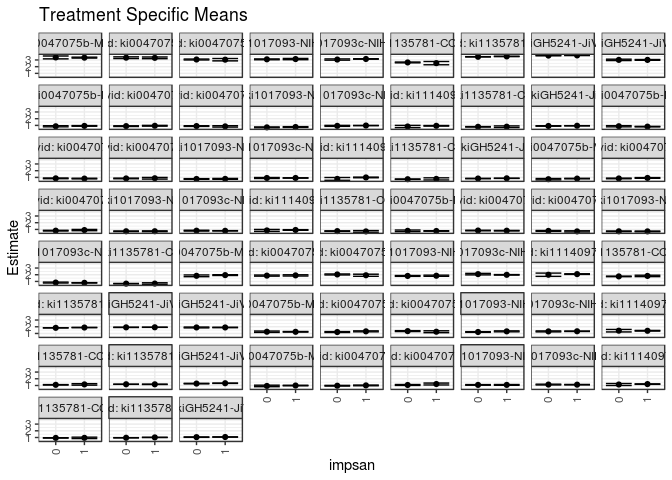

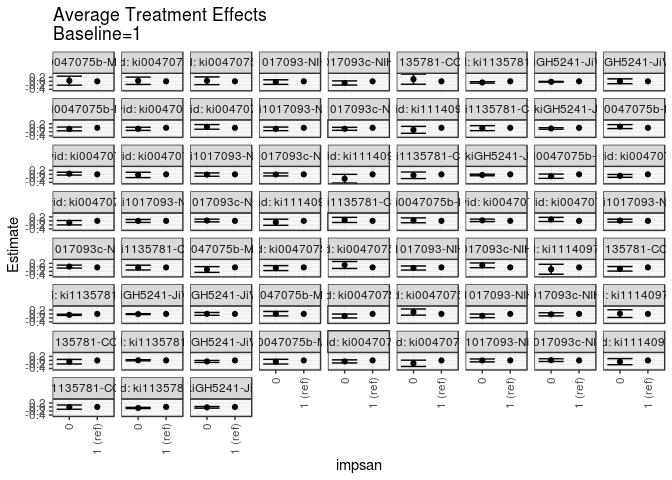

[figure not shown]

## Results Table

### Parameter: TSM

| agecat | studyid | country | intervention_level | baseline_level | estimate | ci_lower | ci_upper |
| --- | --- | --- | --- | --- | --- | --- | --- |
| 0-3 months | ki0047075b-MAL-ED | BANGLADESH | 1 | NA | 3.3415716 | 3.2731861 | 3.4099570 |
| 0-3 months | ki0047075b-MAL-ED | BANGLADESH | 0 | NA | 3.3736455 | 3.1606235 | 3.5866675 |
| 0-3 months | ki0047075b-MAL-ED | INDIA | 1 | NA | 3.3118086 | 3.1832053 | 3.4404118 |
| 0-3 months | ki0047075b-MAL-ED | INDIA | 0 | NA | 3.3383851 | 3.2104503 | 3.4663199 |
| 0-3 months | ki0047075b-MAL-ED | PERU | 1 | NA | 3.0398661 | 2.8635809 | 3.2161513 |
| 0-3 months | ki0047075b-MAL-ED | PERU | 0 | NA | 3.0665718 | 2.9940949 | 3.1390487 |
| 0-3 months | ki1017093-NIH-Birth | BANGLADESH | 1 | NA | 3.1322352 | 3.0385471 | 3.2259233 |
| 0-3 months | ki1017093-NIH-Birth | BANGLADESH | 0 | NA | 3.0937202 | 3.0289913 | 3.1584491 |
| 0-3 months | ki1017093c-NIH-Crypto | BANGLADESH | 1 | NA | 3.1433572 | 3.1039059 | 3.1828085 |
| 0-3 months | ki1017093c-NIH-Crypto | BANGLADESH | 0 | NA | 3.0604309 | 2.9639657 | 3.1568960 |
| 0-3 months | ki1135781-COHORTS | GUATEMALA | 1 | NA | 2.5224604 | 2.2789127 | 2.7660081 |
| 0-3 months | ki1135781-COHORTS | GUATEMALA | 0 | NA | 2.6291746 | 2.5714520 | 2.6868972 |
| 0-3 months | ki1135781-COHORTS | INDIA | 1 | NA | 3.5274935 | 3.4995266 | 3.5554605 |
| 0-3 months | ki1135781-COHORTS | INDIA | 0 | NA | 3.4710076 | 3.4494651 | 3.4925501 |
| 0-3 months | kiGH5241-JiVitA-3 | BANGLADESH | 1 | NA | 3.6737121 | 3.6622674 | 3.6851569 |
| 0-3 months | kiGH5241-JiVitA-3 | BANGLADESH | 0 | NA | 3.6509166 | 3.6329217 | 3.6689114 |
| 0-3 months | kiGH5241-JiVitA-4 | BANGLADESH | 1 | NA | 3.0068284 | 2.9452802 | 3.0683765 |
| 0-3 months | kiGH5241-JiVitA-4 | BANGLADESH | 0 | NA | 3.0093711 | 2.9078353 | 3.1109068 |
| 3-6 months | ki0047075b-MAL-ED | BANGLADESH | 1 | NA | 1.9436748 | 1.8882961 | 1.9990535 |
| 3-6 months | ki0047075b-MAL-ED | BANGLADESH | 0 | NA | 1.8381217 | 1.7081272 | 1.9681161 |
| 3-6 months | ki0047075b-MAL-ED | INDIA | 1 | NA | 1.9033970 | 1.8133524 | 1.9934415 |
| 3-6 months | ki0047075b-MAL-ED | INDIA | 0 | NA | 1.8687705 | 1.7851970 | 1.9523440 |
| 3-6 months | ki0047075b-MAL-ED | PERU | 1 | NA | 1.9240050 | 1.7677664 | 2.0802437 |
| 3-6 months | ki0047075b-MAL-ED | PERU | 0 | NA | 2.0432744 | 1.9701397 | 2.1164091 |
| 3-6 months | ki1017093-NIH-Birth | BANGLADESH | 1 | NA | 1.8511567 | 1.7679569 | 1.9343566 |
| 3-6 months | ki1017093-NIH-Birth | BANGLADESH | 0 | NA | 1.8211553 | 1.7625063 | 1.8798044 |
| 3-6 months | ki1017093c-NIH-Crypto | BANGLADESH | 1 | NA | 1.9899004 | 1.9517772 | 2.0280236 |
| 3-6 months | ki1017093c-NIH-Crypto | BANGLADESH | 0 | NA | 2.0919986 | 1.9820603 | 2.2019368 |
| 3-6 months | ki1114097-CONTENT | PERU | 1 | NA | 2.0918849 | 2.0424471 | 2.1413227 |
| 3-6 months | ki1114097-CONTENT | PERU | 0 | NA | 1.9993480 | 1.7571892 | 2.2415069 |

[output cut: 102 more lines]

### Parameter: E(Y)

| agecat | studyid | country | intervention_level | baseline_level | estimate | ci_lower | ci_upper |
| --- | --- | --- | --- | --- | --- | --- | --- |
| 0-3 months | ki0047075b-MAL-ED | BANGLADESH | NA | NA | 3.3470101 | 3.2814494 | 3.4125709 |
| 0-3 months | ki0047075b-MAL-ED | INDIA | NA | NA | 3.3257529 | 3.2359780 | 3.4155278 |
| 0-3 months | ki0047075b-MAL-ED | PERU | NA | NA | 3.0728777 | 3.0062000 | 3.1395554 |
| 0-3 months | ki1017093-NIH-Birth | BANGLADESH | NA | NA | 3.1100116 | 3.0566021 | 3.1634210 |
| 0-3 months | ki1017093c-NIH-Crypto | BANGLADESH | NA | NA | 3.1335342 | 3.0968946 | 3.1701738 |
| 0-3 months | ki1135781-COHORTS | GUATEMALA | NA | NA | 2.6177358 | 2.5631597 | 2.6723119 |
| 0-3 months | ki1135781-COHORTS | INDIA | NA | NA | 3.4938034 | 3.4771179 | 3.5104888 |
| 0-3 months | kiGH5241-JiVitA-3 | BANGLADESH | NA | NA | 3.6645010 | 3.6542693 | 3.6747327 |
| 0-3 months | kiGH5241-JiVitA-4 | BANGLADESH | NA | NA | 3.0081001 | 2.9551156 | 3.0610847 |
| 3-6 months | ki0047075b-MAL-ED | BANGLADESH | NA | NA | 1.9276407 | 1.8774065 | 1.9778750 |
| 3-6 months | ki0047075b-MAL-ED | INDIA | NA | NA | 1.8780654 | 1.8173074 | 1.9388233 |
| 3-6 months | ki0047075b-MAL-ED | PERU | NA | NA | 2.0175680 | 1.9512051 | 2.0839310 |
| 3-6 months | ki1017093-NIH-Birth | BANGLADESH | NA | NA | 1.8326915 | 1.7846731 | 1.8807099 |
| 3-6 months | ki1017093c-NIH-Crypto | BANGLADESH | NA | NA | 2.0027540 | 1.9667312 | 2.0387768 |
| 3-6 months | ki1114097-CONTENT | PERU | NA | NA | 2.0841841 | 2.0362519 | 2.1321163 |
| 3-6 months | ki1135781-COHORTS | GUATEMALA | NA | NA | 1.7541195 | 1.7166655 | 1.7915734 |
| 3-6 months | ki1135781-COHORTS | INDIA | NA | NA | 1.8572103 | 1.8432112 | 1.8712094 |
| 3-6 months | kiGH5241-JiVitA-3 | BANGLADESH | NA | NA | 1.9202191 | 1.9097529 | 1.9306852 |
| 3-6 months | kiGH5241-JiVitA-4 | BANGLADESH | NA | NA | 1.8987567 | 1.8688242 | 1.9286892 |
| 6-9 months | ki0047075b-MAL-ED | BANGLADESH | NA | NA | 1.2480451 | 1.2083209 | 1.2877694 |
| 6-9 months | ki0047075b-MAL-ED | INDIA | NA | NA | 1.2581259 | 1.2101884 | 1.3060633 |
| 6-9 months | ki0047075b-MAL-ED | PERU | NA | NA | 1.3204373 | 1.2649539 | 1.3759207 |
| 6-9 months | ki1017093-NIH-Birth | BANGLADESH | NA | NA | 1.2555950 | 1.2150667 | 1.2961234 |
| 6-9 months | ki1017093c-NIH-Crypto | BANGLADESH | NA | NA | 1.3277672 | 1.2982110 | 1.3573234 |
| 6-9 months | ki1114097-CONTENT | PERU | NA | NA | 1.3974236 | 1.3502187 | 1.4446285 |
| 6-9 months | ki1135781-COHORTS | GUATEMALA | NA | NA | 1.1046168 | 1.0728025 | 1.1364310 |
| 6-9 months | ki1135781-COHORTS | INDIA | NA | NA | 1.1818282 | 1.1689263 | 1.1947301 |
| 6-9 months | kiGH5241-JiVitA-4 | BANGLADESH | NA | NA | 1.3241671 | 1.3034835 | 1.3448507 |
| 9-12 months | ki0047075b-MAL-ED | BANGLADESH | NA | NA | 0.9896446 | 0.9509752 | 1.0283140 |
| 9-12 months | ki0047075b-MAL-ED | INDIA | NA | NA | 0.9810598 | 0.9425271 | 1.0195925 |
| 9-12 months | ki0047075b-MAL-ED | PERU | NA | NA | 1.0938158 | 1.0421876 | 1.1454440 |
| 9-12 months | ki1017093-NIH-Birth | BANGLADESH | NA | NA | 1.0885809 | 1.0534446 | 1.1237171 |
| 9-12 months | ki1017093c-NIH-Crypto | BANGLADESH | NA | NA | 1.1253061 | 1.0988172 | 1.1517949 |
| 9-12 months | ki1114097-CONTENT | PERU | NA | NA | 1.2048768 | 1.1650186 | 1.2447350 |
| 9-12 months | ki1135781-COHORTS | GUATEMALA | NA | NA | 0.9427431 | 0.9140297 | 0.9714566 |
| 9-12 months | ki1135781-COHORTS | INDIA | NA | NA | 0.9844431 | 0.9705367 | 0.9983496 |
| 9-12 months | kiGH5241-JiVitA-4 | BANGLADESH | NA | NA | 1.0714466 | 1.0534634 | 1.0894298 |
| 12-15 months | ki0047075b-MAL-ED | BANGLADESH | NA | NA | 0.9141004 | 0.8737459 | 0.9544550 |
| 12-15 months | ki0047075b-MAL-ED | INDIA | NA | NA | 0.9129447 | 0.8748557 | 0.9510337 |
| 12-15 months | ki0047075b-MAL-ED | PERU | NA | NA | 0.8895957 | 0.8424004 | 0.9367911 |
| 12-15 months | ki1017093-NIH-Birth | BANGLADESH | NA | NA | 0.7241623 | 0.6797013 | 0.7686233 |
| 12-15 months | ki1017093c-NIH-Crypto | BANGLADESH | NA | NA | 0.9714857 | 0.9466423 | 0.9963290 |
| 12-15 months | ki1114097-CONTENT | PERU | NA | NA | 0.9291443 | 0.8867697 | 0.9715190 |
| 12-15 months | ki1135781-COHORTS | GUATEMALA | NA | NA | 0.7899732 | 0.7616006 | 0.8183457 |
| 12-15 months | kiGH5241-JiVitA-4 | BANGLADESH | NA | NA | 0.9414130 | 0.9256041 | 0.9572219 |
| 15-18 months | ki0047075b-MAL-ED | BANGLADESH | NA | NA | 0.8241226 | 0.7871907 | 0.8610544 |
| 15-18 months | ki0047075b-MAL-ED | INDIA | NA | NA | 0.8461081 | 0.8096109 | 0.8826053 |
| 15-18 months | ki0047075b-MAL-ED | PERU | NA | NA | 0.8582871 | 0.8154498 | 0.9011244 |
| 15-18 months | ki1017093-NIH-Birth | BANGLADESH | NA | NA | 0.7727719 | 0.7325606 | 0.8129832 |
| 15-18 months | ki1017093c-NIH-Crypto | BANGLADESH | NA | NA | 0.9162288 | 0.8930973 | 0.9393604 |
| 15-18 months | ki1114097-CONTENT | PERU | NA | NA | 0.9860231 | 0.9406097 | 1.0314365 |
| 15-18 months | ki1135781-COHORTS | GUATEMALA | NA | NA | 0.7357057 | 0.7024388 | 0.7689726 |
| 15-18 months | kiGH5241-JiVitA-4 | BANGLADESH | NA | NA | 0.8599047 | 0.8433807 | 0.8764287 |
| 18-21 months | ki0047075b-MAL-ED | BANGLADESH | NA | NA | 0.8133847 | 0.7790076 | 0.8477619 |
| 18-21 months | ki0047075b-MAL-ED | INDIA | NA | NA | 0.8786990 | 0.8431802 | 0.9142178 |
| 18-21 months | ki0047075b-MAL-ED | PERU | NA | NA | 0.8405408 | 0.7957138 | 0.8853678 |
| 18-21 months | ki1017093-NIH-Birth | BANGLADESH | NA | NA | 0.7291468 | 0.6930874 | 0.7652062 |
| 18-21 months | ki1017093c-NIH-Crypto | BANGLADESH | NA | NA | 0.7977951 | 0.7741689 | 0.8214214 |
| 18-21 months | ki1114097-CONTENT | PERU | NA | NA | 0.9146338 | 0.8709588 | 0.9583088 |
| 18-21 months | ki1135781-COHORTS | GUATEMALA | NA | NA | 0.7453230 | 0.7139167 | 0.7767294 |
| 21-24 months | ki0047075b-MAL-ED | BANGLADESH | NA | NA | 0.7694183 | 0.7339448 | 0.8048918 |
| 21-24 months | ki0047075b-MAL-ED | INDIA | NA | NA | 0.8256267 | 0.7945621 | 0.8566913 |
| 21-24 months | ki0047075b-MAL-ED | PERU | NA | NA | 0.7622936 | 0.7156467 | 0.8089404 |
| 21-24 months | ki1017093-NIH-Birth | BANGLADESH | NA | NA | 0.7172178 | 0.6817161 | 0.7527194 |
| 21-24 months | ki1017093c-NIH-Crypto | BANGLADESH | NA | NA | 0.8010871 | 0.7761614 | 0.8260128 |
| 21-24 months | ki1135781-COHORTS | GUATEMALA | NA | NA | 0.6771703 | 0.6513485 | 0.7029921 |

### Parameter: ATE

| agecat | studyid | country | intervention_level | baseline_level | estimate | ci_lower | ci_upper |
| --- | --- | --- | --- | --- | --- | --- | --- |
| 0-3 months | ki0047075b-MAL-ED | BANGLADESH | 1 | 1 | 0.0000000 | 0.0000000 | 0.0000000 |
| 0-3 months | ki0047075b-MAL-ED | BANGLADESH | 0 | 1 | 0.0320739 | -0.1915341 | 0.2556819 |
| 0-3 months | ki0047075b-MAL-ED | INDIA | 1 | 1 | 0.0000000 | 0.0000000 | 0.0000000 |
| 0-3 months | ki0047075b-MAL-ED | INDIA | 0 | 1 | 0.0265765 | -0.1558089 | 0.2089620 |
| 0-3 months | ki0047075b-MAL-ED | PERU | 1 | 1 | 0.0000000 | 0.0000000 | 0.0000000 |
| 0-3 months | ki0047075b-MAL-ED | PERU | 0 | 1 | 0.0267057 | -0.1641715 | 0.2175829 |
| 0-3 months | ki1017093-NIH-Birth | BANGLADESH | 1 | 1 | 0.0000000 | 0.0000000 | 0.0000000 |
| 0-3 months | ki1017093-NIH-Birth | BANGLADESH | 0 | 1 | -0.0385150 | -0.1525123 | 0.0754823 |
| 0-3 months | ki1017093c-NIH-Crypto | BANGLADESH | 1 | 1 | 0.0000000 | 0.0000000 | 0.0000000 |
| 0-3 months | ki1017093c-NIH-Crypto | BANGLADESH | 0 | 1 | -0.0829263 | -0.1871646 | 0.0213120 |
| 0-3 months | ki1135781-COHORTS | GUATEMALA | 1 | 1 | 0.0000000 | 0.0000000 | 0.0000000 |
| 0-3 months | ki1135781-COHORTS | GUATEMALA | 0 | 1 | 0.1067142 | -0.1444197 | 0.3578481 |
| 0-3 months | ki1135781-COHORTS | INDIA | 1 | 1 | 0.0000000 | 0.0000000 | 0.0000000 |
| 0-3 months | ki1135781-COHORTS | INDIA | 0 | 1 | -0.0564859 | -0.0912865 | -0.0216853 |
| 0-3 months | kiGH5241-JiVitA-3 | BANGLADESH | 1 | 1 | 0.0000000 | 0.0000000 | 0.0000000 |
| 0-3 months | kiGH5241-JiVitA-3 | BANGLADESH | 0 | 1 | -0.0227956 | -0.0417080 | -0.0038832 |
| 0-3 months | kiGH5241-JiVitA-4 | BANGLADESH | 1 | 1 | 0.0000000 | 0.0000000 | 0.0000000 |
| 0-3 months | kiGH5241-JiVitA-4 | BANGLADESH | 0 | 1 | 0.0025427 | -0.1166062 | 0.1216915 |
| 3-6 months | ki0047075b-MAL-ED | BANGLADESH | 1 | 1 | 0.0000000 | 0.0000000 | 0.0000000 |
| 3-6 months | ki0047075b-MAL-ED | BANGLADESH | 0 | 1 | -0.1055531 | -0.2478939 | 0.0367877 |
| 3-6 months | ki0047075b-MAL-ED | INDIA | 1 | 1 | 0.0000000 | 0.0000000 | 0.0000000 |
| 3-6 months | ki0047075b-MAL-ED | INDIA | 0 | 1 | -0.0346265 | -0.1580465 | 0.0887935 |
| 3-6 months | ki0047075b-MAL-ED | PERU | 1 | 1 | 0.0000000 | 0.0000000 | 0.0000000 |
| 3-6 months | ki0047075b-MAL-ED | PERU | 0 | 1 | 0.1192694 | -0.0535601 | 0.2920988 |
| 3-6 months | ki1017093-NIH-Birth | BANGLADESH | 1 | 1 | 0.0000000 | 0.0000000 | 0.0000000 |
| 3-6 months | ki1017093-NIH-Birth | BANGLADESH | 0 | 1 | -0.0300014 | -0.1316349 | 0.0716320 |
| 3-6 months | ki1017093c-NIH-Crypto | BANGLADESH | 1 | 1 | 0.0000000 | 0.0000000 | 0.0000000 |
| 3-6 months | ki1017093c-NIH-Crypto | BANGLADESH | 0 | 1 | 0.1020981 | -0.0141756 | 0.2183719 |
| 3-6 months | ki1114097-CONTENT | PERU | 1 | 1 | 0.0000000 | 0.0000000 | 0.0000000 |
| 3-6 months | ki1114097-CONTENT | PERU | 0 | 1 | -0.0925369 | -0.3389643 | 0.1538906 |

[output cut: 102 more lines]

### Parameter: PAR

| agecat | studyid | country | intervention_level | baseline_level | estimate | ci_lower | ci_upper |
| --- | --- | --- | --- | --- | --- | --- | --- |
| 0-3 months | ki0047075b-MAL-ED | BANGLADESH | 1 | NA | 0.0054386 | -0.0266687 | 0.0375458 |
| 0-3 months | ki0047075b-MAL-ED | INDIA | 1 | NA | 0.0139443 | -0.0855212 | 0.1134099 |
| 0-3 months | ki0047075b-MAL-ED | PERU | 1 | NA | 0.0330116 | -0.1206988 | 0.1867220 |
| 0-3 months | ki1017093-NIH-Birth | BANGLADESH | 1 | NA | -0.0222236 | -0.0933008 | 0.0488536 |
| 0-3 months | ki1017093c-NIH-Crypto | BANGLADESH | 1 | NA | -0.0098229 | -0.0221600 | 0.0025141 |
| 0-3 months | ki1135781-COHORTS | GUATEMALA | 1 | NA | 0.0952754 | -0.1390625 | 0.3296132 |
| 0-3 months | ki1135781-COHORTS | INDIA | 1 | NA | -0.0336902 | -0.0564331 | -0.0109473 |
| 0-3 months | kiGH5241-JiVitA-3 | BANGLADESH | 1 | NA | -0.0092111 | -0.0150484 | -0.0033738 |
| 0-3 months | kiGH5241-JiVitA-4 | BANGLADESH | 1 | NA | 0.0012717 | -0.0260519 | 0.0285953 |
| 3-6 months | ki0047075b-MAL-ED | BANGLADESH | 1 | NA | -0.0160341 | -0.0389990 | 0.0069308 |
| 3-6 months | ki0047075b-MAL-ED | INDIA | 1 | NA | -0.0253316 | -0.0923410 | 0.0416778 |
| 3-6 months | ki0047075b-MAL-ED | PERU | 1 | NA | 0.0935630 | -0.0481462 | 0.2352722 |
| 3-6 months | ki1017093-NIH-Birth | BANGLADESH | 1 | NA | -0.0184652 | -0.0819674 | 0.0450370 |
| 3-6 months | ki1017093c-NIH-Crypto | BANGLADESH | 1 | NA | 0.0128536 | -0.0008908 | 0.0265979 |
| 3-6 months | ki1114097-CONTENT | PERU | 1 | NA | -0.0077008 | -0.0211051 | 0.0057035 |
| 3-6 months | ki1135781-COHORTS | GUATEMALA | 1 | NA | -0.0690999 | -0.1725012 | 0.0343015 |
| 3-6 months | ki1135781-COHORTS | INDIA | 1 | NA | -0.0292167 | -0.0479786 | -0.0104549 |
| 3-6 months | kiGH5241-JiVitA-3 | BANGLADESH | 1 | NA | -0.0016971 | -0.0082629 | 0.0048687 |
| 3-6 months | kiGH5241-JiVitA-4 | BANGLADESH | 1 | NA | 0.0013384 | -0.0145266 | 0.0172035 |
| 6-9 months | ki0047075b-MAL-ED | BANGLADESH | 1 | NA | 0.0013531 | -0.0176552 | 0.0203615 |
| 6-9 months | ki0047075b-MAL-ED | INDIA | 1 | NA | -0.0589844 | -0.1119691 | -0.0059997 |
| 6-9 months | ki0047075b-MAL-ED | PERU | 1 | NA | 0.0604350 | -0.0707299 | 0.1916000 |
| 6-9 months | ki1017093-NIH-Birth | BANGLADESH | 1 | NA | -0.0597416 | -0.1139057 | -0.0055775 |
| 6-9 months | ki1017093c-NIH-Crypto | BANGLADESH | 1 | NA | -0.0012493 | -0.0113334 | 0.0088348 |
| 6-9 months | ki1114097-CONTENT | PERU | 1 | NA | -0.0033974 | -0.0143109 | 0.0075161 |
| 6-9 months | ki1135781-COHORTS | GUATEMALA | 1 | NA | -0.0578800 | -0.1623102 | 0.0465502 |
| 6-9 months | ki1135781-COHORTS | INDIA | 1 | NA | 0.0059504 | -0.0124109 | 0.0243118 |
| 6-9 months | kiGH5241-JiVitA-4 | BANGLADESH | 1 | NA | -0.0106043 | -0.0210768 | -0.0001318 |
| 9-12 months | ki0047075b-MAL-ED | BANGLADESH | 1 | NA | -0.0046611 | -0.0223680 | 0.0130458 |
| 9-12 months | ki0047075b-MAL-ED | INDIA | 1 | NA | -0.0324239 | -0.0742525 | 0.0094047 |
| 9-12 months | ki0047075b-MAL-ED | PERU | 1 | NA | -0.1248706 | -0.2559410 | 0.0061998 |
| 9-12 months | ki1017093-NIH-Birth | BANGLADESH | 1 | NA | 0.0010009 | -0.0426398 | 0.0446417 |
| 9-12 months | ki1017093c-NIH-Crypto | BANGLADESH | 1 | NA | 0.0023675 | -0.0066433 | 0.0113783 |
| 9-12 months | ki1114097-CONTENT | PERU | 1 | NA | -0.0033434 | -0.0128077 | 0.0061209 |
| 9-12 months | ki1135781-COHORTS | GUATEMALA | 1 | NA | -0.0055768 | -0.1039607 | 0.0928071 |
| 9-12 months | ki1135781-COHORTS | INDIA | 1 | NA | -0.0294947 | -0.0479483 | -0.0110411 |
| 9-12 months | kiGH5241-JiVitA-4 | BANGLADESH | 1 | NA | -0.0033319 | -0.0123335 | 0.0056698 |
| 12-15 months | ki0047075b-MAL-ED | BANGLADESH | 1 | NA | -0.0082760 | -0.0222940 | 0.0057419 |
| 12-15 months | ki0047075b-MAL-ED | INDIA | 1 | NA | -0.0280765 | -0.0707932 | 0.0146401 |
| 12-15 months | ki0047075b-MAL-ED | PERU | 1 | NA | 0.0379049 | -0.0545750 | 0.1303848 |
| 12-15 months | ki1017093-NIH-Birth | BANGLADESH | 1 | NA | -0.0324567 | -0.0866807 | 0.0217673 |
| 12-15 months | ki1017093c-NIH-Crypto | BANGLADESH | 1 | NA | -0.0065045 | -0.0161476 | 0.0031386 |
| 12-15 months | ki1114097-CONTENT | PERU | 1 | NA | -0.0064712 | -0.0176002 | 0.0046578 |
| 12-15 months | ki1135781-COHORTS | GUATEMALA | 1 | NA | -0.0159168 | -0.1321060 | 0.1002723 |
| 12-15 months | kiGH5241-JiVitA-4 | BANGLADESH | 1 | NA | -0.0050962 | -0.0133667 | 0.0031742 |
| 15-18 months | ki0047075b-MAL-ED | BANGLADESH | 1 | NA | 0.0092734 | -0.0056379 | 0.0241847 |
| 15-18 months | ki0047075b-MAL-ED | INDIA | 1 | NA | 0.0201633 | -0.0186874 | 0.0590140 |
| 15-18 months | ki0047075b-MAL-ED | PERU | 1 | NA | -0.0179491 | -0.1264945 | 0.0905962 |
| 15-18 months | ki1017093-NIH-Birth | BANGLADESH | 1 | NA | -0.0077882 | -0.0571296 | 0.0415533 |
| 15-18 months | ki1017093c-NIH-Crypto | BANGLADESH | 1 | NA | -0.0006877 | -0.0107023 | 0.0093270 |
| 15-18 months | ki1114097-CONTENT | PERU | 1 | NA | -0.0083488 | -0.0219280 | 0.0052303 |
| 15-18 months | ki1135781-COHORTS | GUATEMALA | 1 | NA | -0.0429218 | -0.1956813 | 0.1098377 |
| 15-18 months | kiGH5241-JiVitA-4 | BANGLADESH | 1 | NA | -0.0066907 | -0.0149109 | 0.0015295 |
| 18-21 months | ki0047075b-MAL-ED | BANGLADESH | 1 | NA | -0.0128739 | -0.0282611 | 0.0025132 |
| 18-21 months | ki0047075b-MAL-ED | INDIA | 1 | NA | -0.0417724 | -0.0801008 | -0.0034439 |
| 18-21 months | ki0047075b-MAL-ED | PERU | 1 | NA | -0.0643803 | -0.1499317 | 0.0211710 |
| 18-21 months | ki1017093-NIH-Birth | BANGLADESH | 1 | NA | -0.0022630 | -0.0469291 | 0.0424031 |
| 18-21 months | ki1017093c-NIH-Crypto | BANGLADESH | 1 | NA | 0.0023666 | -0.0061614 | 0.0108946 |
| 18-21 months | ki1114097-CONTENT | PERU | 1 | NA | -0.0034158 | -0.0140129 | 0.0071813 |
| 18-21 months | ki1135781-COHORTS | GUATEMALA | 1 | NA | 0.0407206 | -0.0783215 | 0.1597626 |
| 21-24 months | ki0047075b-MAL-ED | BANGLADESH | 1 | NA | 0.0025542 | -0.0124946 | 0.0176029 |
| 21-24 months | ki0047075b-MAL-ED | INDIA | 1 | NA | 0.0140878 | -0.0195797 | 0.0477552 |
| 21-24 months | ki0047075b-MAL-ED | PERU | 1 | NA | 0.0535736 | -0.0227576 | 0.1299049 |
| 21-24 months | ki1017093-NIH-Birth | BANGLADESH | 1 | NA | 0.0069734 | -0.0360045 | 0.0499512 |
| 21-24 months | ki1017093c-NIH-Crypto | BANGLADESH | 1 | NA | 0.0058852 | -0.0049273 | 0.0166977 |
| 21-24 months | ki1135781-COHORTS | GUATEMALA | 1 | NA | -0.0080868 | -0.1185515 | 0.1023778 |